# Temnos2021Analysis

# Visualizing worker data

### Behavior Code

At this point, we need to remove pupae from dataset.

```r
workerdata<-subset(workerdata,Behavior.Code!="Pupa")
queendata<-subset(queendata,Behavior.Code!="Pupa")
```

Do nurses and foragers have the same amount of venom? Do workers in queenright colonies have the same amount of venom as workers in queenless colonies? Do callow workers have the same amount of venom as melanized workers? Graph it.

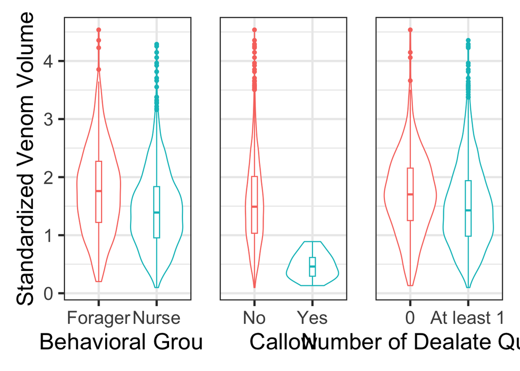

```r
venombybehavior<-ggplot(workerdata,aes(Behavior.Code,standardizedvenom*1000,color=Behavior.Code))+
geom_violin()+
  geom_boxplot(width=0.1)+
  xlab("Behavioral Group")+ylab("Standardized Venom Volume")+theme_bw(base_size = 22)+
  theme(legend.position="none")+
scale_colour_discrete("")

venombyqueenright<-ggplot(workerdata,aes(as.factor(Queen.Count>0),standardizedvenom*1000, color=as.factor(Queen.Count>0)))+
geom_violin()+
  geom_boxplot(width=0.1)+
  xlab("Number of Dealate Queens")+ylab("Standardized Venom Volume")+theme_bw(base_size = 22)+
  theme(legend.position="none")+
  scale_x_discrete(labels = c('0','At least 1'))

callowplot = ggplot(data=workerdata,aes(x=Callow, y=standardizedvenom*1000, color=Callow)) + geom_violin() +geom_boxplot(width=0.1)+
xlab("Callow")+ylab("Standardized Venom Volume")+theme_bw(base_size = 22)+theme(legend.position = "none")+ scale_x_discrete(labels=c("No", "Yes"))

remove_y <- theme(
  axis.text.y = element_blank(),
  axis.ticks.y = element_blank(),
  axis.title.y = element_blank()
)

p=list(venombybehavior,callowplot+remove_y,venombyqueenright+remove_y)

wrap_plots(p, nrow = 1)
```

```r
ggsave('workers2021',plot=wrap_plots(p, nrow = 1),dpi=900,width =39, height = 15, units = "cm",device='png')
```

This first block is for worker venom volume, P1a. First, lets represent graphically.

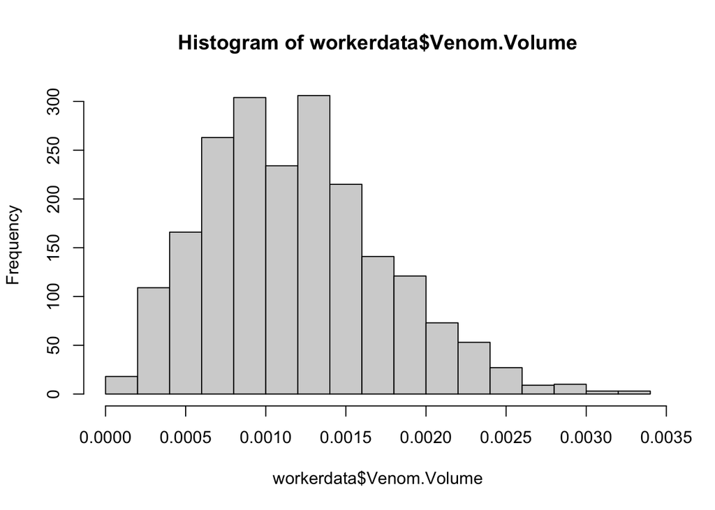

```r
#now the initial model, which looks for an interaction effect between behavior and pupae count, and between behavior and adult count.

#exclude dissected pupae from dataset (we already did above, but no problem to have code 2x in case do not run above chunk)
workerdata<-subset(workerdata, Behavior.Code!="Pupa")

hist(workerdata$Venom.Volume)
```

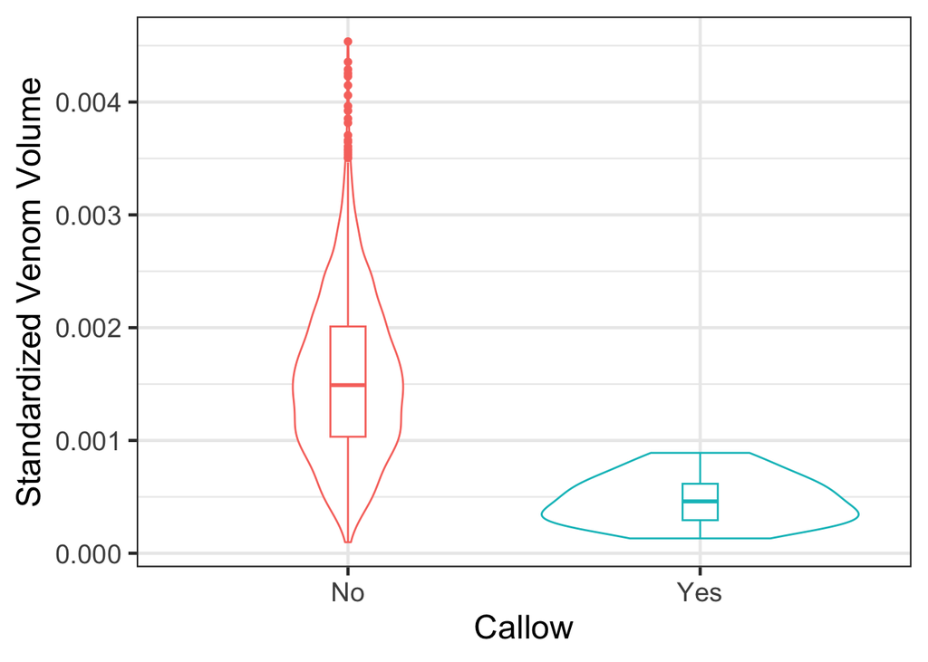

```r
#A bit right skewed

callowplot = ggplot(data=workerdata,aes(x=Callow, y=standardizedvenom, color=Callow)) + geom_violin() +geom_boxplot(width=0.1)+
xlab("Callow")+ylab("Standardized Venom Volume")+theme_bw(base_size = 18)+theme(legend.position = "none")+ scale_x_discrete(labels=c("No", "Yes"))
callowplot
```

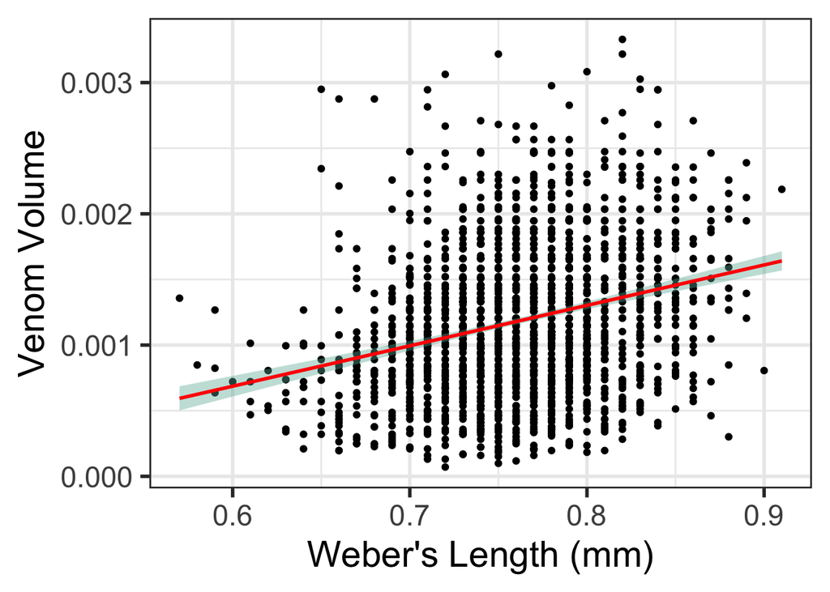

```r
venombysize = ggplot(data=workerdata,aes(x=Webers.Length.mm, y=Venom.Volume)) + geom_point() +
  xlab("Weber's Length (mm)")+ylab("Venom Volume")+theme_bw(base_size = 22)+geom_smooth(method=lm , color="red", fill="#69b3a2", se=TRUE)
venombysize
```

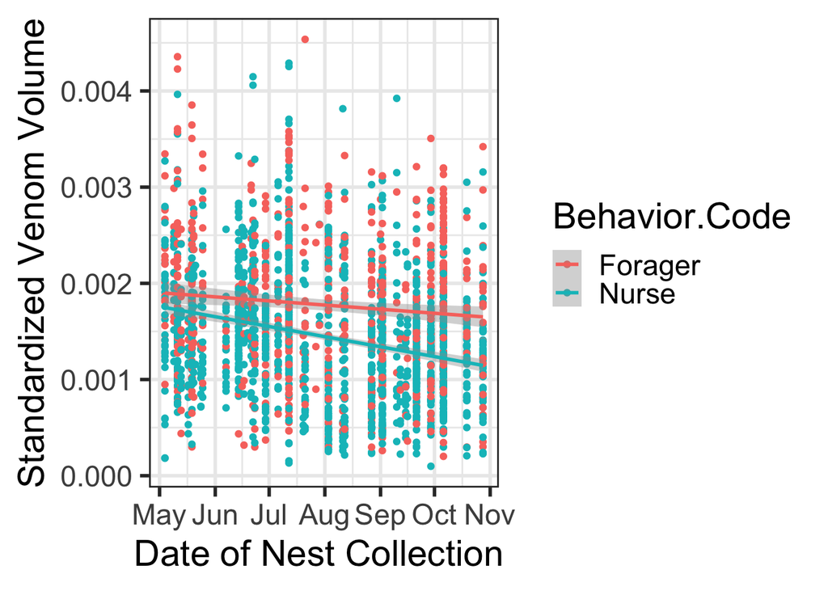

```r
venombydate = ggplot(data=workerdata, aes(Date.Collected.D.M,standardizedvenom,color=Behavior.Code)) +
geom_point() +
  scale_x_date(date_breaks = "months" , date_labels = "%b")+
geom_smooth(method=lm, se=TRUE ) +
xlab("Date of Nest Collection ")+
ylab("Standardized Venom Volume")+
theme_bw(base_size = 22)
venombydate
```

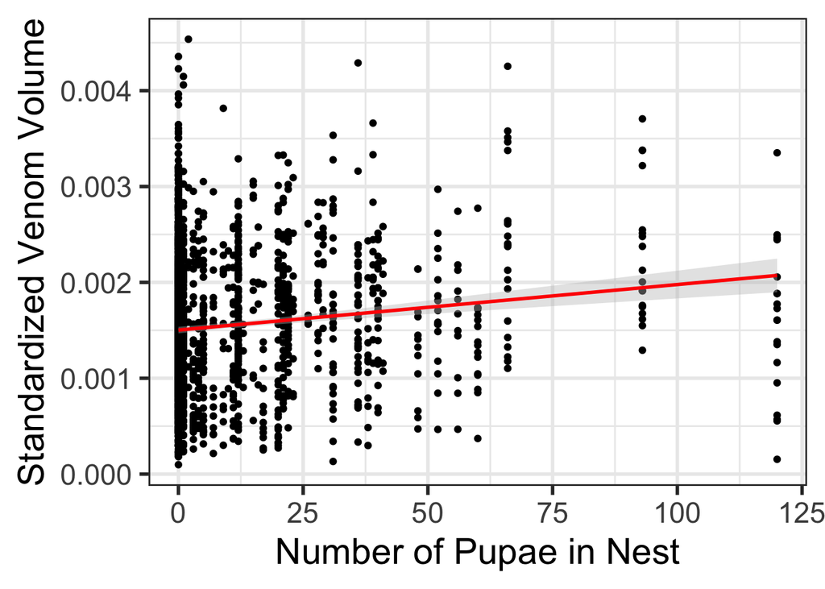

```r
venombypupae = ggplot(data=workerdata, aes(Pupae.Count,standardizedvenom)) +
geom_point() +
geom_smooth(method=lm, color="red", fill="gray", se=TRUE) +
xlab("Number of Pupae in Nest")+
ylab("Standardized Venom Volume")+
theme_bw(base_size = 22)
venombypupae
```

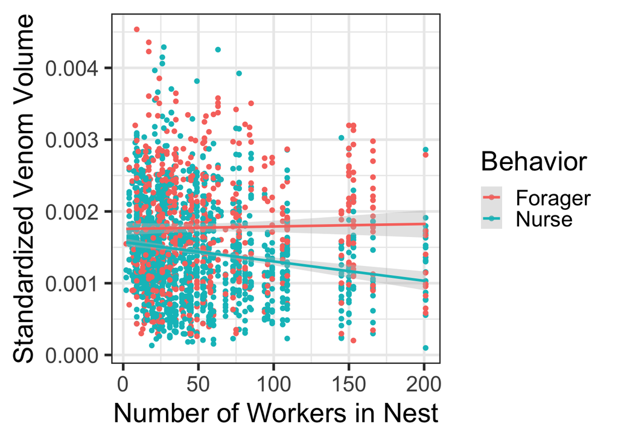

```r
venombyadultinteraction=ggplot(data=workerdata, aes(Adult.Count,standardizedvenom, color=Behavior.Code)) +
geom_point() +
geom_smooth(method=lm, fill="gray", se=TRUE) +
xlab("Number of Workers in Nest")+
ylab("Standardized Venom Volume")+
theme_bw(base_size = 22)+
scale_colour_discrete("Behavior")
venombyadultinteraction
```

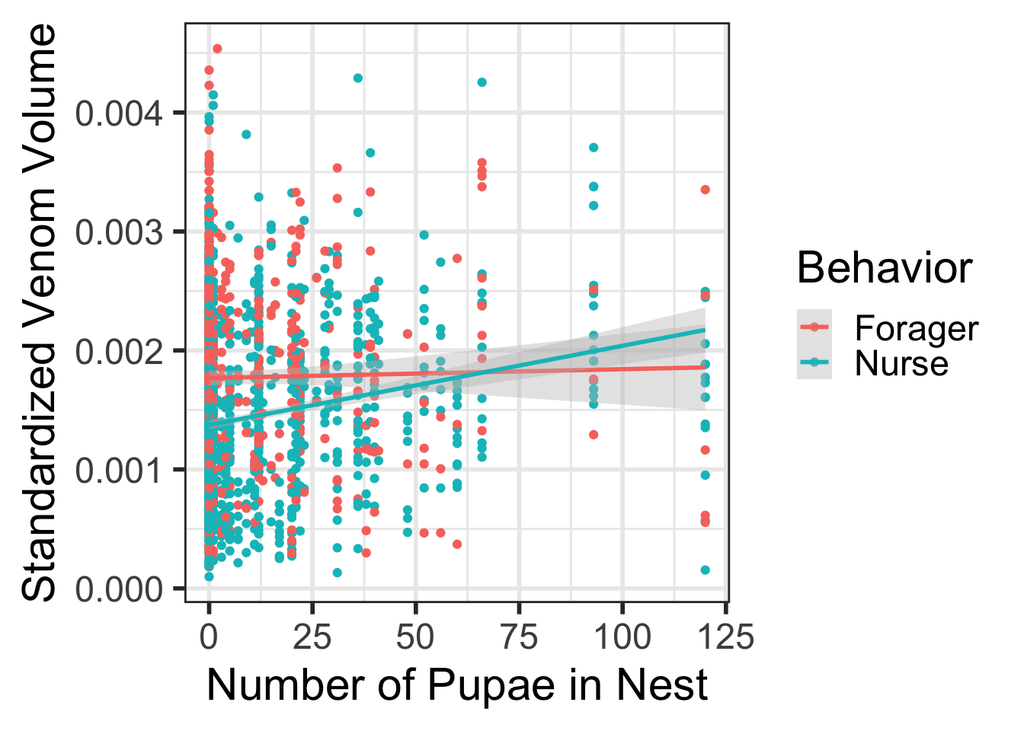

```r
venombypupaeinteraction=ggplot(data=workerdata, aes(Pupae.Count,standardizedvenom, color=Behavior.Code)) +
geom_point() +
geom_smooth(method=lm, fill="gray", se=TRUE) +
xlab("Number of Pupae in Nest")+
ylab("Standardized Venom Volume")+
theme_bw(base_size = 22)+
scale_colour_discrete("Behavior")
venombypupaeinteraction
```

# Modeling Worker data

### by worker

Next, lets run a generalized linear mixed-effects model

```r
workerdata$Pupae.Adult.Ratio=workerdata$Pupae.Count/workerdata$Adult.Count
workerdata$Larvae.Adult.Ratio=workerdata$Larvae.Count/workerdata$Adult.Count
workerdata$Young.Adult.Ratio=(workerdata$Larvae.Count+workerdata$Pupae.Count)/workerdata$Adult.Count

model1<-lme(standardizedvenom~Callow+Date.Collected.D.M+Behavior.Code*Adult.Count.Scaled+Behavior.Code*Pupae.Adult.Ratio+as.factor(Queen.Count>0)+Larvae.Adult.Ratio+Winged.Queen.Count, data=workerdata, random= ~1|Colony)
summary(model1)
```

```
## Linear mixed-effects model fit by REML
##   Data: workerdata
##         AIC       BIC   logLik
##   -24150.26 -24077.17 12088.13
##
## Random effects:
##  Formula: ~1 | Colony
##          (Intercept)     Residual
## StdDev: 0.0002636282 0.0006149078
##
## Fixed effects:  standardizedvenom ~ Callow + Date.Collected.D.M + Behavior.Code *      Adult.Count.Scaled + Behavior.Code * Pupae.Adult.Ratio +      as.factor(Queen.Count > 0) + Larvae.Adult.Ratio + Winged.Queen.Count
##                                             Value   Std.Error   DF   t-value
## (Intercept)                            0.05352632 0.011209831 1896  4.774945
## CallowTRUE                            -0.00078629 0.000164218 1896 -4.788066
## Date.Collected.D.M                    -0.00000274 0.000000596  148 -4.606475
## Behavior.CodeNurse                    -0.00033917 0.000038089 1896 -8.904794
## Adult.Count.Scaled                     0.00006884 0.000033440  148  2.058709
## Pupae.Adult.Ratio                     -0.00003838 0.000041805  148 -0.918072
## as.factor(Queen.Count > 0)TRUE        -0.00013013 0.000062782  148 -2.072670
## Larvae.Adult.Ratio                    -0.00000731 0.000019206  148 -0.380865
## Winged.Queen.Count                     0.00001790 0.000014002  148  1.278468
## Behavior.CodeNurse:Adult.Count.Scaled -0.00005834 0.000023462 1896 -2.486606
## Behavior.CodeNurse:Pupae.Adult.Ratio   0.00017319 0.000040550 1896  4.270889
##                                       p-value
## (Intercept)                            0.0000
## CallowTRUE                             0.0000
## Date.Collected.D.M                     0.0000
## Behavior.CodeNurse                     0.0000
## Adult.Count.Scaled                     0.0413
## Pupae.Adult.Ratio                      0.3601
## as.factor(Queen.Count > 0)TRUE         0.0399
## Larvae.Adult.Ratio                     0.7038
## Winged.Queen.Count                     0.2031
## Behavior.CodeNurse:Adult.Count.Scaled  0.0130
## Behavior.CodeNurse:Pupae.Adult.Ratio   0.0000
##  Correlation:
##                                       (Intr) ClTRUE D.C.D. Bhv.CN Ad.C.S Pp.A.R
## CallowTRUE                             0.008
## Date.Collected.D.M                    -1.000 -0.008
## Behavior.CodeNurse                     0.033 -0.043 -0.035
```

[output cut: 10 more lines]

```
## Behavior.CodeNurse
## Adult.Count.Scaled
## Pupae.Adult.Ratio
## as.factor(Queen.Count > 0)TRUE
## Larvae.Adult.Ratio                    -0.126
## Winged.Queen.Count                     0.078  0.127
## Behavior.CodeNurse:Adult.Count.Scaled  0.000  0.016 -0.006
## Behavior.CodeNurse:Pupae.Adult.Ratio  -0.018  0.006  0.012  0.285
##
## Standardized Within-Group Residuals:
##         Min          Q1         Med          Q3         Max
## -2.99439650 -0.64839849 -0.07111591  0.57624205  4.02681168
##
## Number of Observations: 2055
## Number of Groups: 155
```

```r
emtrends(model1,pairwise~Behavior.Code, var = "Pupae.Adult.Ratio",infer=TRUE)
```

```
## $emtrends
##  Behavior.Code Pupae.Adult.Ratio.trend       SE  df  lower.CL upper.CL t.ratio
##  Forager                     -3.84e-05 4.18e-05 148 -1.21e-04 4.42e-05  -0.918
##  Nurse                        1.35e-04 3.30e-05 148  6.96e-05 2.00e-04   4.084
##  p.value
##   0.3601
##   0.0001
##
## Results are averaged over the levels of: Callow, Queen.Count
## Degrees-of-freedom method: containment
## Confidence level used: 0.95
##
## $contrasts
##  contrast         estimate       SE   df  lower.CL  upper.CL t.ratio p.value
##  Forager - Nurse -0.000173 4.06e-05 1896 -0.000253 -9.37e-05  -4.271  <.0001
##
## Results are averaged over the levels of: Callow, Queen.Count
## Degrees-of-freedom method: containment
## Confidence level used: 0.95
```

```r
emtrends(model1,pairwise~Behavior.Code, var = "Adult.Count.Scaled",infer=TRUE)
```

```
## $emtrends
##  Behavior.Code Adult.Count.Scaled.trend       SE  df  lower.CL upper.CL t.ratio
##  Forager                       6.88e-05 3.34e-05 148  2.76e-06 1.35e-04   2.059
##  Nurse                         1.05e-05 3.10e-05 148 -5.08e-05 7.18e-05   0.339
##  p.value
##   0.0413
##   0.7354
##
## Results are averaged over the levels of: Callow, Queen.Count
## Degrees-of-freedom method: containment
## Confidence level used: 0.95
##
## $contrasts
##  contrast        estimate       SE   df lower.CL upper.CL t.ratio p.value
##  Forager - Nurse 5.83e-05 2.35e-05 1896 1.23e-05 0.000104   2.487  0.0130
##
## Results are averaged over the levels of: Callow, Queen.Count
## Degrees-of-freedom method: containment
## Confidence level used: 0.95
```

```r
#Remove Larvae.Adult.Ratio from model

model2<-lme(standardizedvenom~Callow+Date.Collected.D.M+Behavior.Code*Adult.Count.Scaled+Behavior.Code*Pupae.Adult.Ratio+as.factor(Queen.Count>0)+Winged.Queen.Count, data=workerdata, random= ~1|Colony)
summary(model2)
```

```
## Linear mixed-effects model fit by REML
##   Data: workerdata
##         AIC       BIC logLik
##   -24172.01 -24104.53  12098
##
## Random effects:
##  Formula: ~1 | Colony
##          (Intercept)     Residual
## StdDev: 0.0002622825 0.0006149282
##
## Fixed effects:  standardizedvenom ~ Callow + Date.Collected.D.M + Behavior.Code *      Adult.Count.Scaled + Behavior.Code * Pupae.Adult.Ratio +      as.factor(Queen.Count > 0) + Winged.Queen.Count
##                                             Value   Std.Error   DF   t-value
## (Intercept)                            0.05298013 0.011078777 1896  4.782128
## CallowTRUE                            -0.00078591 0.000164173 1896 -4.787087
## Date.Collected.D.M                    -0.00000272 0.000000589  149 -4.611115
## Behavior.CodeNurse                    -0.00033929 0.000038083 1896 -8.909271
## Adult.Count.Scaled                     0.00007143 0.000032653  149  2.187422
## Pupae.Adult.Ratio                     -0.00003591 0.000041239  149 -0.870808
## as.factor(Queen.Count > 0)TRUE        -0.00013322 0.000062073  149 -2.146260
## Winged.Queen.Count                     0.00001856 0.000013836  149  1.341105
## Behavior.CodeNurse:Adult.Count.Scaled -0.00005822 0.000023458 1896 -2.481818
## Behavior.CodeNurse:Pupae.Adult.Ratio   0.00017331 0.000040547 1896  4.274238
##                                       p-value
## (Intercept)                            0.0000
## CallowTRUE                             0.0000
## Date.Collected.D.M                     0.0000
## Behavior.CodeNurse                     0.0000
## Adult.Count.Scaled                     0.0303
## Pupae.Adult.Ratio                      0.3853
## as.factor(Queen.Count > 0)TRUE         0.0335
## Winged.Queen.Count                     0.1819
## Behavior.CodeNurse:Adult.Count.Scaled  0.0132
## Behavior.CodeNurse:Pupae.Adult.Ratio   0.0000
##  Correlation:
##                                       (Intr) ClTRUE D.C.D. Bhv.CN Ad.C.S Pp.A.R
## CallowTRUE                             0.010
## Date.Collected.D.M                    -1.000 -0.010
## Behavior.CodeNurse                     0.032 -0.043 -0.035
## Adult.Count.Scaled                     0.443 -0.001 -0.444  0.256
## Pupae.Adult.Ratio                      0.010  0.008 -0.011  0.326  0.236
## as.factor(Queen.Count > 0)TRUE         0.090  0.012 -0.094 -0.018 -0.097 -0.028
## Winged.Queen.Count                     0.067 -0.035 -0.068  0.017  0.048 -0.015
## Behavior.CodeNurse:Adult.Count.Scaled -0.010  0.006  0.011 -0.490 -0.464 -0.187
## Behavior.CodeNurse:Pupae.Adult.Ratio  -0.022 -0.014  0.023 -0.486 -0.144 -0.689
##                                       a.(Q>0 Wn.Q.C B.CN:A
## CallowTRUE
## Date.Collected.D.M
## Behavior.CodeNurse
## Adult.Count.Scaled
## Pupae.Adult.Ratio
## as.factor(Queen.Count > 0)TRUE
## Winged.Queen.Count                     0.096
## Behavior.CodeNurse:Adult.Count.Scaled  0.002 -0.008
## Behavior.CodeNurse:Pupae.Adult.Ratio  -0.017  0.011  0.284
##
## Standardized Within-Group Residuals:
##         Min          Q1         Med          Q3         Max
## -2.99504811 -0.64781564 -0.06893942  0.57367586  4.03163427
##
## Number of Observations: 2055
## Number of Groups: 155
```

```r
emtrends(model2,pairwise~Behavior.Code, var = "Pupae.Adult.Ratio",infer=TRUE)
```

```
## $emtrends
##  Behavior.Code Pupae.Adult.Ratio.trend       SE  df  lower.CL upper.CL t.ratio
##  Forager                     -3.59e-05 4.12e-05 149 -1.17e-04 4.56e-05  -0.871
##  Nurse                        1.37e-04 3.22e-05 149  7.37e-05 2.01e-04   4.262
##  p.value
##   0.3853
##   <.0001
##
## Results are averaged over the levels of: Callow, Queen.Count
## Degrees-of-freedom method: containment
## Confidence level used: 0.95
##
## $contrasts
##  contrast         estimate       SE   df  lower.CL  upper.CL t.ratio p.value
##  Forager - Nurse -0.000173 4.05e-05 1896 -0.000253 -9.38e-05  -4.274  <.0001
##
## Results are averaged over the levels of: Callow, Queen.Count
## Degrees-of-freedom method: containment
## Confidence level used: 0.95
```

```r
emtrends(model2,pairwise~Behavior.Code, var = "Adult.Count.Scaled",infer=TRUE)
```

```
## $emtrends
##  Behavior.Code Adult.Count.Scaled.trend       SE  df  lower.CL upper.CL t.ratio
##  Forager                       7.14e-05 3.27e-05 149  6.90e-06 1.36e-04   2.187
##  Nurse                         1.32e-05 3.01e-05 149 -4.62e-05 7.27e-05   0.439
##  p.value
##   0.0303
##   0.6612
##
## Results are averaged over the levels of: Callow, Queen.Count
## Degrees-of-freedom method: containment
## Confidence level used: 0.95
##
## $contrasts
##  contrast        estimate       SE   df lower.CL upper.CL t.ratio p.value
##  Forager - Nurse 5.82e-05 2.35e-05 1896 1.22e-05 0.000104   2.482  0.0132
##
## Results are averaged over the levels of: Callow, Queen.Count
## Degrees-of-freedom method: containment
## Confidence level used: 0.95
```

```r
#Remove Winged.Queen.Count from model

model3<-lme(standardizedvenom~Callow+Behavior.Code*Adult.Count.Scaled+Date.Collected.D.M+Behavior.Code*Pupae.Adult.Ratio+as.factor(Queen.Count>0), data=workerdata, random= ~1|Colony)
summary(model3)
```

```
## Linear mixed-effects model fit by REML
##   Data: workerdata
##         AIC       BIC   logLik
##   -24192.75 -24130.89 12107.37
##
## Random effects:
##  Formula: ~1 | Colony
##          (Intercept)     Residual
## StdDev: 0.0002624909 0.0006150299
##
## Fixed effects:  standardizedvenom ~ Callow + Behavior.Code * Adult.Count.Scaled +      Date.Collected.D.M + Behavior.Code * Pupae.Adult.Ratio +      as.factor(Queen.Count > 0)
##                                             Value   Std.Error   DF   t-value
## (Intercept)                            0.05197702 0.011060078 1896  4.699516
## CallowTRUE                            -0.00077813 0.000164103 1896 -4.741713
## Behavior.CodeNurse                    -0.00034018 0.000038084 1896 -8.932296
## Adult.Count.Scaled                     0.00006934 0.000032634  150  2.124655
## Date.Collected.D.M                    -0.00000266 0.000000588  150 -4.527375
## Pupae.Adult.Ratio                     -0.00003508 0.000041249  150 -0.850460
## as.factor(Queen.Count > 0)TRUE        -0.00014120 0.000061823  150 -2.283883
## Behavior.CodeNurse:Adult.Count.Scaled -0.00005795 0.000023461 1896 -2.470043
## Behavior.CodeNurse:Pupae.Adult.Ratio   0.00017271 0.000040552 1896  4.258932
##                                       p-value
## (Intercept)                            0.0000
## CallowTRUE                             0.0000
## Behavior.CodeNurse                     0.0000
## Adult.Count.Scaled                     0.0353
## Date.Collected.D.M                     0.0000
## Pupae.Adult.Ratio                      0.3964
## as.factor(Queen.Count > 0)TRUE         0.0238
## Behavior.CodeNurse:Adult.Count.Scaled  0.0136
## Behavior.CodeNurse:Pupae.Adult.Ratio   0.0000
##  Correlation:
##                                       (Intr) ClTRUE Bhv.CN Ad.C.S D.C.D. Pp.A.R
## CallowTRUE                             0.013
## Behavior.CodeNurse                     0.031 -0.042
## Adult.Count.Scaled                     0.442  0.001  0.255
## Date.Collected.D.M                    -1.000 -0.013 -0.033 -0.442
## Pupae.Adult.Ratio                      0.011  0.008  0.326  0.237 -0.012
## as.factor(Queen.Count > 0)TRUE         0.084  0.016 -0.020 -0.102 -0.088 -0.027
## Behavior.CodeNurse:Adult.Count.Scaled -0.009  0.006 -0.490 -0.464  0.010 -0.187
## Behavior.CodeNurse:Pupae.Adult.Ratio  -0.023 -0.014 -0.486 -0.145  0.024 -0.689
##                                       a.(Q>0 B.CN:A
## CallowTRUE
## Behavior.CodeNurse
## Adult.Count.Scaled
## Date.Collected.D.M
## Pupae.Adult.Ratio
## as.factor(Queen.Count > 0)TRUE
## Behavior.CodeNurse:Adult.Count.Scaled  0.003
## Behavior.CodeNurse:Pupae.Adult.Ratio  -0.019  0.285
##
## Standardized Within-Group Residuals:
##         Min          Q1         Med          Q3         Max
## -2.99671084 -0.65095358 -0.07172188  0.57447689  4.02938992
##
## Number of Observations: 2055
## Number of Groups: 155
```

```r
emtrends(model3,pairwise~Behavior.Code, var = "Pupae.Adult.Ratio",infer=TRUE)
```

```
## $emtrends
##  Behavior.Code Pupae.Adult.Ratio.trend       SE  df  lower.CL upper.CL t.ratio
##  Forager                     -3.51e-05 4.12e-05 150 -1.17e-04 4.64e-05  -0.850
##  Nurse                        1.38e-04 3.23e-05 150  7.39e-05 2.01e-04   4.267
##  p.value
##   0.3964
##   <.0001
##
## Results are averaged over the levels of: Callow, Queen.Count
## Degrees-of-freedom method: containment
## Confidence level used: 0.95
##
## $contrasts
##  contrast         estimate       SE   df  lower.CL  upper.CL t.ratio p.value
##  Forager - Nurse -0.000173 4.06e-05 1896 -0.000252 -9.32e-05  -4.259  <.0001
##
## Results are averaged over the levels of: Callow, Queen.Count
## Degrees-of-freedom method: containment
## Confidence level used: 0.95
```

```r
emtrends(model3,pairwise~Behavior.Code, var = "Adult.Count.Scaled",infer=TRUE)
```

```
## $emtrends
##  Behavior.Code Adult.Count.Scaled.trend       SE  df  lower.CL upper.CL t.ratio
##  Forager                       6.93e-05 3.26e-05 150  4.85e-06 1.34e-04   2.125
##  Nurse                         1.14e-05 3.01e-05 150 -4.80e-05 7.08e-05   0.379
##  p.value
##   0.0353
##   0.7055
##
## Results are averaged over the levels of: Callow, Queen.Count
## Degrees-of-freedom method: containment
## Confidence level used: 0.95
##
## $contrasts
##  contrast        estimate       SE   df lower.CL upper.CL t.ratio p.value
##  Forager - Nurse 5.79e-05 2.35e-05 1896 1.19e-05 0.000104   2.470  0.0136
##
## Results are averaged over the levels of: Callow, Queen.Count
## Degrees-of-freedom method: containment
## Confidence level used: 0.95
```

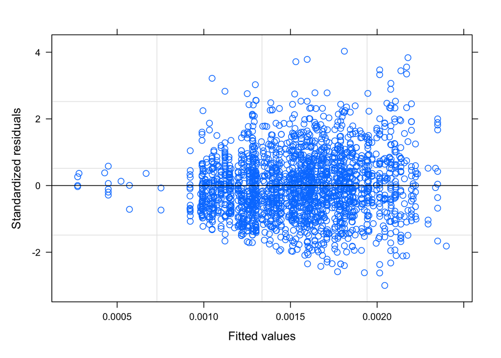

```r
#Callow workers have significantly less venom
#Workers have less venom as season progresses from may to october
#significant interaction effect between behavior and adult count
#significant interaction effect between behavior and pupae count

plot(model3)
```

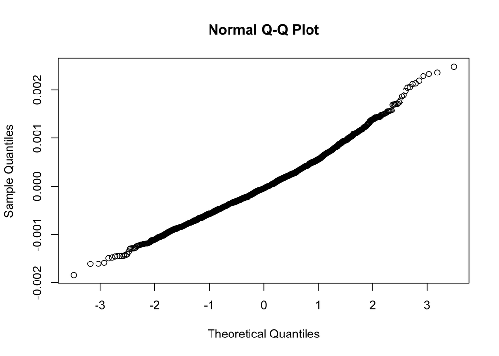

```r
qqnorm(resid(model3))
```

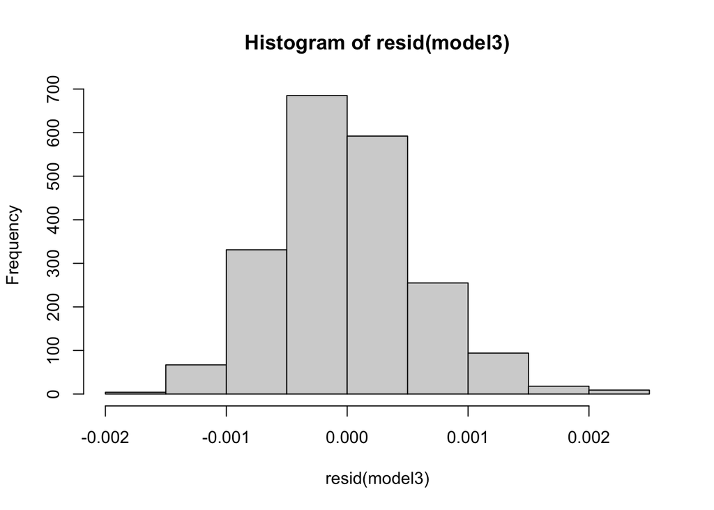

```r
hist(resid(model3))
```

```r
#Overall, slopes are significantly different from each other. MEANING that the slope for nurses to predict venom based on adult count is significantly different than that of foragers, and same for pupae.
#For Pupae adult ratio, slope for nurses is the only one that is significantly different than 0. So as the number of pupae in a colony increase, the nurses in that colony have more venom.
#This is another way to do an ad hoc test below. Basically, this code says at -1,0,and 1, slopes for nurses and foragers are significantly different from each other. Here it is only written for worker count
pairs(emmeans(model3, ~ Behavior.Code * Adult.Count.Scaled,at=list(Adult.Count.Scaled=c(-1,0,1))))
```

```
##  contrast                                                       estimate
##  (Forager Adult.Count.Scaled-1) - (Nurse Adult.Count.Scaled-1)  2.17e-04
##  (Forager Adult.Count.Scaled-1) - Forager Adult.Count.Scaled0  -6.93e-05
##  (Forager Adult.Count.Scaled-1) - Nurse Adult.Count.Scaled0     2.05e-04
##  (Forager Adult.Count.Scaled-1) - Forager Adult.Count.Scaled1  -1.39e-04
##  (Forager Adult.Count.Scaled-1) - Nurse Adult.Count.Scaled1     1.94e-04
##  (Nurse Adult.Count.Scaled-1) - Forager Adult.Count.Scaled0    -2.86e-04
##  (Nurse Adult.Count.Scaled-1) - Nurse Adult.Count.Scaled0      -1.14e-05
##  (Nurse Adult.Count.Scaled-1) - Forager Adult.Count.Scaled1    -3.55e-04
##  (Nurse Adult.Count.Scaled-1) - Nurse Adult.Count.Scaled1      -2.28e-05
##  Forager Adult.Count.Scaled0 - Nurse Adult.Count.Scaled0        2.75e-04
##  Forager Adult.Count.Scaled0 - Forager Adult.Count.Scaled1     -6.93e-05
##  Forager Adult.Count.Scaled0 - Nurse Adult.Count.Scaled1        2.63e-04
##  Nurse Adult.Count.Scaled0 - Forager Adult.Count.Scaled1       -3.44e-04
##  Nurse Adult.Count.Scaled0 - Nurse Adult.Count.Scaled1         -1.14e-05
##  Forager Adult.Count.Scaled1 - Nurse Adult.Count.Scaled1        3.33e-04
##        SE   df t.ratio p.value
##  4.83e-05 1896   4.480  0.0001
##  3.26e-05  150  -2.125  0.2803
##  5.17e-05  150   3.971  0.0015
##  6.53e-05  150  -2.125  0.2803
##  6.94e-05  150   2.794  0.0639
##  4.69e-05  150  -6.092  <.0001
##  3.01e-05  150  -0.379  0.9990
##  6.48e-05  150  -5.483  <.0001
##  6.01e-05  150  -0.379  0.9990
##  3.34e-05 1896   8.213  <.0001
##  3.26e-05  150  -2.125  0.2803
##  4.29e-05  150   6.134  <.0001
##  4.12e-05  150  -8.355  <.0001
##  3.01e-05  150  -0.379  0.9990
##  3.16e-05 1896  10.524  <.0001
##
## Results are averaged over the levels of: Callow, Queen.Count
## Degrees-of-freedom method: containment
## P value adjustment: tukey method for comparing a family of 6 estimates
```

```r
pairs(emmeans(model3, ~ Behavior.Code | Adult.Count.Scaled,at=list(Adult.Count.Scaled=c(-1,0,1))))
```

```
## Adult.Count.Scaled = -1:
##  contrast        estimate       SE   df t.ratio p.value
##  Forager - Nurse 0.000217 4.83e-05 1896   4.480  <.0001
##
## Adult.Count.Scaled =  0:
##  contrast        estimate       SE   df t.ratio p.value
##  Forager - Nurse 0.000275 3.34e-05 1896   8.213  <.0001
##
## Adult.Count.Scaled =  1:
##  contrast        estimate       SE   df t.ratio p.value
##  Forager - Nurse 0.000333 3.16e-05 1896  10.524  <.0001
##
## Results are averaged over the levels of: Callow, Queen.Count
## Degrees-of-freedom method: containment
```

In this chunk, I am using the performance package function check_collinearity to test if date and pupae are collinear (and a problem), since pupae are only existant at certain points during the season

```r
check_collinearity(model3)
```

```
## # Check for Multicollinearity
##
## Low Correlation
##
##                              Term  VIF     VIF 95% CI Increased SE Tolerance
##                            Callow 1.00 [1.00, 225.37]         1.00      1.00
##                     Behavior.Code 1.60 [1.51,   1.70]         1.26      0.63
##                Adult.Count.Scaled 1.86 [1.75,   1.99]         1.36      0.54
##                Date.Collected.D.M 1.39 [1.32,   1.47]         1.18      0.72
##                 Pupae.Adult.Ratio 2.04 [1.92,   2.18]         1.43      0.49
##        as.factor(Queen.Count > 0) 1.04 [1.01,   1.13]         1.02      0.96
##  Behavior.Code:Adult.Count.Scaled 1.70 [1.61,   1.82]         1.31      0.59
##   Behavior.Code:Pupae.Adult.Ratio 2.31 [2.16,   2.47]         1.52      0.43
##  Tolerance 95% CI
##      [0.00, 1.00]
##      [0.59, 0.66]
##      [0.50, 0.57]
##      [0.68, 0.76]
##      [0.46, 0.52]
##      [0.89, 0.99]
##      [0.55, 0.62]
##      [0.40, 0.46]
```

```r
#No problems here! All well under 5, and even under 3.
```

### Breakpoint

Investigating the idea of a breakpoint analysis. Ultimately decided to use date as a continuous variable because it’s hard to determine how to bin date.

```r
#Pupae first in colonies on june 14. Almost none after august 20

for (row in 1:nrow(workerdata)) {

    if(workerdata$Date.Collected.D.M[row]<"2021-06-14") {
        workerdata$Raid.Potential[row]="too early"
        }else if(workerdata$Date.Collected.D.M[row]>"2021-08-20"){workerdata$Raid.Potential[row]="too late"
  }else{workerdata$Raid.Potential[row]="raids possible"}
}
workerdata$Raid.Potential <- factor(workerdata$Raid.Potential, levels = c("too early", "raids possible", "too late"))
breakpointmodel<-lme(standardizedvenom~Callow+Raid.Potential+Behavior.Code*Adult.Count.Scaled+Behavior.Code*Pupae.Adult.Ratio+as.factor(Queen.Count>0), data=workerdata, random= ~1|Colony)
summary(breakpointmodel)
```

```
## Linear mixed-effects model fit by REML
##   Data: workerdata
##         AIC       BIC   logLik
##   -24179.67 -24112.19 12101.84
##
## Random effects:
##  Formula: ~1 | Colony
##          (Intercept)     Residual
## StdDev: 0.0002683308 0.0006150688
##
## Fixed effects:  standardizedvenom ~ Callow + Raid.Potential + Behavior.Code *      Adult.Count.Scaled + Behavior.Code * Pupae.Adult.Ratio +      as.factor(Queen.Count > 0)
##                                               Value    Std.Error   DF   t-value
## (Intercept)                            0.0020222862 7.295014e-05 1896 27.721484
## CallowTRUE                            -0.0007923336 1.644006e-04 1896 -4.819529
## Raid.Potentialraids possible          -0.0000867576 7.881765e-05  149 -1.100738
## Raid.Potentialtoo late                -0.0003184087 8.121220e-05  149 -3.920700
## Behavior.CodeNurse                    -0.0003388527 3.814120e-05 1896 -8.884165
## Adult.Count.Scaled                     0.0000655997 3.334324e-05  149  1.967405
## Pupae.Adult.Ratio                     -0.0000474365 4.639849e-05  149 -1.022371
## as.factor(Queen.Count > 0)TRUE        -0.0001456756 6.267870e-05  149 -2.324164
## Behavior.CodeNurse:Adult.Count.Scaled -0.0000580296 2.347719e-05 1896 -2.471745
## Behavior.CodeNurse:Pupae.Adult.Ratio   0.0001730084 4.057373e-05 1896  4.264050
##                                       p-value
## (Intercept)                            0.0000
## CallowTRUE                             0.0000
## Raid.Potentialraids possible           0.2728
## Raid.Potentialtoo late                 0.0001
## Behavior.CodeNurse                     0.0000
## Adult.Count.Scaled                     0.0510
## Pupae.Adult.Ratio                      0.3083
## as.factor(Queen.Count > 0)TRUE         0.0215
## Behavior.CodeNurse:Adult.Count.Scaled  0.0135
## Behavior.CodeNurse:Pupae.Adult.Ratio   0.0000
##  Correlation:
##                                       (Intr) ClTRUE Rd.Ptp Rd.Ptl Bhv.CN Ad.C.S
## CallowTRUE                             0.005
## Raid.Potentialraids possible          -0.495 -0.042
## Raid.Potentialtoo late                -0.486  0.000  0.503
## Behavior.CodeNurse                    -0.313 -0.042 -0.036 -0.050
## Adult.Count.Scaled                     0.089 -0.011 -0.104 -0.437  0.255
## Pupae.Adult.Ratio                     -0.064  0.028 -0.411 -0.059  0.298  0.171
## as.factor(Queen.Count > 0)TRUE        -0.584  0.013 -0.007 -0.072 -0.020 -0.104
## Behavior.CodeNurse:Adult.Count.Scaled  0.160  0.005  0.021  0.017 -0.490 -0.456
## Behavior.CodeNurse:Pupae.Adult.Ratio   0.168 -0.014  0.018  0.026 -0.486 -0.142
##                                       Pp.A.R a.(Q>0 B.CN:A
## CallowTRUE
## Raid.Potentialraids possible
## Raid.Potentialtoo late
## Behavior.CodeNurse
## Adult.Count.Scaled
## Pupae.Adult.Ratio
## as.factor(Queen.Count > 0)TRUE        -0.037
## Behavior.CodeNurse:Adult.Count.Scaled -0.174  0.003
## Behavior.CodeNurse:Pupae.Adult.Ratio  -0.617 -0.018  0.285
##
## Standardized Within-Group Residuals:
##         Min          Q1         Med          Q3         Max
## -3.00245342 -0.64496064 -0.06928748  0.57093296  4.01715710
##
## Number of Observations: 2055
## Number of Groups: 155
```

```r
emtrends(breakpointmodel,pairwise~Behavior.Code, var = "Adult.Count.Scaled",infer=TRUE)
```

```
## $emtrends
##  Behavior.Code Adult.Count.Scaled.trend       SE  df  lower.CL upper.CL t.ratio
##  Forager                       6.56e-05 3.33e-05 149 -2.87e-07 1.31e-04   1.967
##  Nurse                         7.57e-06 3.08e-05 149 -5.33e-05 6.84e-05   0.246
##  p.value
##   0.0510
##   0.8062
##
## Results are averaged over the levels of: Callow, Raid.Potential, Queen.Count
## Degrees-of-freedom method: containment
## Confidence level used: 0.95
##
## $contrasts
##  contrast        estimate       SE   df lower.CL upper.CL t.ratio p.value
##  Forager - Nurse  5.8e-05 2.35e-05 1896  1.2e-05 0.000104   2.472  0.0135
##
## Results are averaged over the levels of: Callow, Raid.Potential, Queen.Count
## Degrees-of-freedom method: containment
## Confidence level used: 0.95
```

```r
emtrends(breakpointmodel,pairwise~Behavior.Code, var = "Pupae.Adult.Ratio",infer=TRUE)
```

```
## $emtrends
##  Behavior.Code Pupae.Adult.Ratio.trend       SE  df  lower.CL upper.CL t.ratio
##  Forager                     -4.74e-05 4.64e-05 149 -1.39e-04 4.42e-05  -1.022
##  Nurse                        1.26e-04 3.84e-05 149  4.96e-05 2.02e-04   3.267
##  p.value
##   0.3083
##   0.0014
##
## Results are averaged over the levels of: Callow, Raid.Potential, Queen.Count
## Degrees-of-freedom method: containment
## Confidence level used: 0.95
##
## $contrasts
##  contrast         estimate       SE   df  lower.CL  upper.CL t.ratio p.value
##  Forager - Nurse -0.000173 4.06e-05 1896 -0.000253 -9.34e-05  -4.264  <.0001
##
## Results are averaged over the levels of: Callow, Raid.Potential, Queen.Count
## Degrees-of-freedom method: containment
## Confidence level used: 0.95
```

```r
emmeans(breakpointmodel, specs = pairwise ~ Raid.Potential)
```

```
## $emmeans
##  Raid.Potential  emmean       SE  df lower.CL upper.CL
##  too early      0.00136 1.04e-04 149  0.00115  0.00156
##  raids possible 0.00127 9.57e-05 149  0.00108  0.00146
##  too late       0.00104 9.67e-05 149  0.00085  0.00123
##
## Results are averaged over the levels of: Callow, Behavior.Code, Queen.Count
## Degrees-of-freedom method: containment
## Confidence level used: 0.95
##
## $contrasts
##  contrast                   estimate       SE  df t.ratio p.value
##  too early - raids possible 8.68e-05 7.88e-05 149   1.101  0.5151
##  too early - too late       3.18e-04 8.12e-05 149   3.921  0.0004
##  raids possible - too late  2.32e-04 7.98e-05 149   2.904  0.0118
##
## Results are averaged over the levels of: Callow, Behavior.Code, Queen.Count
## Degrees-of-freedom method: containment
## P value adjustment: tukey method for comparing a family of 3 estimates
```

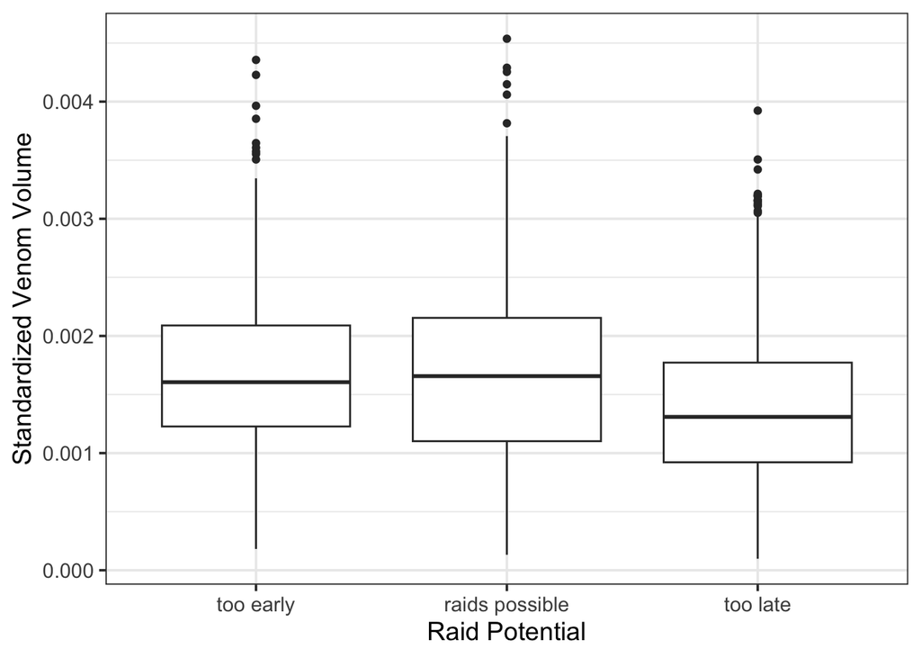

```r
venombyraidpotential<-ggplot(workerdata,aes(Raid.Potential,standardizedvenom),color=Behavior.Code)+
  geom_boxplot()+
  xlab("Raid Potential")+ylab("Standardized Venom Volume")+theme_bw(base_size = 14)+
  theme(legend.position="none")+
scale_colour_discrete("")
venombyraidpotential
```

```r
workerdata$Raid.Potential <- factor(workerdata$Raid.Potential, levels = c("early", "maximum potential", "too late"))
for (row in 1:nrow(workerdata)) {

    if(workerdata$Date.Collected.D.M[row] <"2021-06-15") {
        workerdata$Raid.Potential[row]="early"
    }
  else if (workerdata$Date.Collected.D.M[row]>"2021-07-20"){workerdata$Raid.Potential[row]="too late"}
  else {workerdata$Raid.Potential[row]="maximum potential"}
}


maxraidpotentialmodel<-lme(standardizedvenom~Callow+Raid.Potential*Behavior.Code+Behavior.Code*Adult.Count.Scaled+Behavior.Code*Pupae.Adult.Ratio+as.factor(Queen.Count>0), data=workerdata, random= ~1|Colony)
summary(maxraidpotentialmodel)
```

```
## Linear mixed-effects model fit by REML
##   Data: workerdata
##         AIC       BIC   logLik
##   -24153.36 -24074.65 12090.68
##
## Random effects:
##  Formula: ~1 | Colony
##          (Intercept)     Residual
## StdDev: 0.0002550236 0.0006151882
##
## Fixed effects:  standardizedvenom ~ Callow + Raid.Potential * Behavior.Code +      Behavior.Code * Adult.Count.Scaled + Behavior.Code * Pupae.Adult.Ratio +      as.factor(Queen.Count > 0)
##                                                            Value    Std.Error
## (Intercept)                                         0.0019931226 7.675050e-05
## CallowTRUE                                         -0.0007500305 1.642697e-04
## Raid.Potentialmaximum potential                    -0.0000529405 1.202788e-04
## Raid.Potentialtoo late                             -0.0002419069 8.987558e-05
## Behavior.CodeNurse                                 -0.0003121052 6.503785e-05
## Adult.Count.Scaled                                  0.0000500330 3.227184e-05
## Pupae.Adult.Ratio                                  -0.0000424914 5.384995e-05
## as.factor(Queen.Count > 0)TRUE                     -0.0001271376 6.095606e-05
## Raid.Potentialmaximum potential:Behavior.CodeNurse  0.0001172623 1.165855e-04
## Raid.Potentialtoo late:Behavior.CodeNurse          -0.0000841981 8.587915e-05
## Behavior.CodeNurse:Adult.Count.Scaled              -0.0000398682 2.657305e-05
## Behavior.CodeNurse:Pupae.Adult.Ratio                0.0001171759 5.396654e-05
##                                                      DF   t-value p-value
## (Intercept)                                        1894 25.968853  0.0000
## CallowTRUE                                         1894 -4.565847  0.0000
## Raid.Potentialmaximum potential                     149 -0.440149  0.6605
## Raid.Potentialtoo late                              149 -2.691576  0.0079
## Behavior.CodeNurse                                 1894 -4.798825  0.0000
## Adult.Count.Scaled                                  149  1.550361  0.1232
## Pupae.Adult.Ratio                                   149 -0.789070  0.4313
## as.factor(Queen.Count > 0)TRUE                      149 -2.085725  0.0387
## Raid.Potentialmaximum potential:Behavior.CodeNurse 1894  1.005805  0.3146
## Raid.Potentialtoo late:Behavior.CodeNurse          1894 -0.980425  0.3270
## Behavior.CodeNurse:Adult.Count.Scaled              1894 -1.500323  0.1337
## Behavior.CodeNurse:Pupae.Adult.Ratio               1894  2.171269  0.0300
##  Correlation:
##                                                    (Intr) ClTRUE Rd.Ptp Rd.Ptl
## CallowTRUE                                         -0.010
```

[output cut: 26 more lines]

```
## Behavior.CodeNurse
## Adult.Count.Scaled
## Pupae.Adult.Ratio
## as.factor(Queen.Count > 0)TRUE
## Raid.Potentialmaximum potential:Behavior.CodeNurse
## Raid.Potentialtoo late:Behavior.CodeNurse           0.512
## Behavior.CodeNurse:Adult.Count.Scaled              -0.161 -0.462
## Behavior.CodeNurse:Pupae.Adult.Ratio               -0.618 -0.118  0.185
##
## Standardized Within-Group Residuals:
##         Min          Q1         Med          Q3         Max
## -2.99260496 -0.64299782 -0.07551255  0.58436320  3.97873499
##
## Number of Observations: 2055
## Number of Groups: 155
```

```r
emtrends(maxraidpotentialmodel,pairwise~Behavior.Code, var = "Adult.Count.Scaled",infer=TRUE)
```

```
## $emtrends
##  Behavior.Code Adult.Count.Scaled.trend       SE  df  lower.CL upper.CL t.ratio
##  Forager                       5.00e-05 3.23e-05 149 -1.37e-05 1.14e-04   1.550
##  Nurse                         1.02e-05 2.91e-05 149 -4.74e-05 6.77e-05   0.349
##  p.value
##   0.1232
##   0.7275
##
## Results are averaged over the levels of: Callow, Raid.Potential, Queen.Count
## Degrees-of-freedom method: containment
## Confidence level used: 0.95
##
## $contrasts
##  contrast        estimate       SE   df  lower.CL upper.CL t.ratio p.value
##  Forager - Nurse 3.99e-05 2.66e-05 1894 -1.22e-05  9.2e-05   1.500  0.1337
##
## Results are averaged over the levels of: Callow, Raid.Potential, Queen.Count
## Degrees-of-freedom method: containment
## Confidence level used: 0.95
```

```r
emtrends(maxraidpotentialmodel,pairwise~Behavior.Code, var = "Pupae.Adult.Ratio",infer=TRUE)
```

```
## $emtrends
##  Behavior.Code Pupae.Adult.Ratio.trend       SE  df  lower.CL upper.CL t.ratio
##  Forager                     -4.25e-05 5.38e-05 149 -1.49e-04 6.39e-05  -0.789
##  Nurse                        7.47e-05 4.18e-05 149 -7.99e-06 1.57e-04   1.785
##  p.value
##   0.4313
##   0.0763
##
## Results are averaged over the levels of: Callow, Raid.Potential, Queen.Count
## Degrees-of-freedom method: containment
## Confidence level used: 0.95
##
## $contrasts
##  contrast         estimate      SE   df  lower.CL  upper.CL t.ratio p.value
##  Forager - Nurse -0.000117 5.4e-05 1894 -0.000223 -1.13e-05  -2.171  0.0300
##
## Results are averaged over the levels of: Callow, Raid.Potential, Queen.Count
## Degrees-of-freedom method: containment
## Confidence level used: 0.95
```

```r
emmeans(maxraidpotentialmodel, specs = pairwise ~ Raid.Potential|Behavior.Code)
```

```
## $emmeans
## Behavior.Code = Forager:
##  Raid.Potential      emmean       SE  df lower.CL upper.CL
##  early             0.001514 1.11e-04 149 0.001294  0.00173
##  maximum potential 0.001461 1.21e-04 149 0.001221  0.00170
##  too late          0.001272 9.64e-05 149 0.001082  0.00146
##
## Behavior.Code = Nurse:
##  Raid.Potential      emmean       SE  df lower.CL upper.CL
##  early             0.001224 1.04e-04 149 0.001020  0.00143
##  maximum potential 0.001289 1.10e-04 149 0.001071  0.00151
##  too late          0.000898 8.96e-05 149 0.000721  0.00108
##
## Results are averaged over the levels of: Callow, Queen.Count
## Degrees-of-freedom method: containment
## Confidence level used: 0.95
##
## $contrasts
## Behavior.Code = Forager:
##  contrast                      estimate       SE  df t.ratio p.value
##  early - maximum potential     5.29e-05 1.20e-04 149   0.440  0.8988
##  early - too late              2.42e-04 8.99e-05 149   2.692  0.0215
##  maximum potential - too late  1.89e-04 1.10e-04 149   1.722  0.2003
##
## Behavior.Code = Nurse:
##  contrast                      estimate       SE  df t.ratio p.value
##  early - maximum potential    -6.43e-05 9.64e-05 149  -0.667  0.7827
##  early - too late              3.26e-04 7.47e-05 149   4.366  0.0001
##  maximum potential - too late  3.90e-04 9.08e-05 149   4.299  0.0001
##
## Results are averaged over the levels of: Callow, Queen.Count
## Degrees-of-freedom method: containment
## P value adjustment: tukey method for comparing a family of 3 estimates
```

# Nest data

```r
#Since dataset doesn't have year in same column, we have to jump through some hoops to get this all set up



par(mfrow=c(2,1))
plot(summarydata$Date.Collected,summarydata$Pupae.Count, xlab="Date of Colony Collection", ylab="Pupae Count")

g = ggplot(data=summarydata, aes(x=Date.Collected)) + geom_point(aes(y=Adult.Count),color="red") + geom_point(aes(y=Pupae.Count),color="blue")+ geom_point(aes(y=Larvae.Count),color="orange")+
xlab("Date Collected")+ylab("Nest Census Count")+
theme_bw(base_size = 22)

summarydata$bin <- cut(summarydata$Date.Collected, breaks=c("months"))
ggplot(data=summarydata) + geom_boxplot(aes(bin, Adult.Count),color="red")+ geom_boxplot(aes(bin, Pupae.Count),color="blue")


dat <- reshape2::melt(summarydata, id.vars="Date.Collected",
                      measure.vars=c("Adult.Count", "Larvae.Count","Pupae.Count"))
dat$bin <- cut(dat$Date.Collected, breaks=c("months"))

g<-ggplot(data=dat) + geom_boxplot(aes(bin, value, fill=variable))+
xlab("Date Collected")+
ylab("Nest Census")+
theme_bw(base_size = 20)+
scale_x_discrete(labels=c("May","June","July","Aug","Sep","Oct"))+
theme(legend.position = c(0.095, 0.85),legend.background = element_rect(fill = "white"))+
scale_fill_brewer(palette="BuPu",name = "Ant Type", labels = c("Workers", "Larva", "Pupa"))+
  theme(legend.background = element_rect(colour = 'black', fill = 'white', linetype='solid'))



queen=ggplot(data=summarydata, aes(x=Date.Collected, y=Queen.Count)) + geom_point() +
xlab("Date Collected")+ylab("Number of Dealate Queens")+
theme_bw(base_size = 22)+
scale_x_date(date_breaks = "months" , date_labels = "%b")+
geom_smooth(method='lm', formula= y~x)

censusadult<-lme(Adult.Count~bin, data=summarydata, random= ~1|Colony)
summary(censusadult)
```

```
## Linear mixed-effects model fit by REML
##   Data: summarydata
##        AIC      BIC    logLik
##   1615.255 1640.151 -799.6277
##
## Random effects:
##  Formula: ~1 | Colony
##         (Intercept) Residual
## StdDev:    26.38513 9.894424
##
## Fixed effects:  Adult.Count ~ bin
##                  Value Std.Error  DF   t-value p-value
## (Intercept)   21.51111  4.200727 166  5.120807  0.0000
## bin2021-06-01 -3.72733  6.253606 166 -0.596029  0.5520
## bin2021-07-01 -1.02835  6.710290 166 -0.153250  0.8784
## bin2021-08-01 25.10794  7.447092 166  3.371509  0.0009
## bin2021-09-01 29.64889  7.029160 166  4.217985  0.0000
## bin2021-10-01 53.15556  8.401453 166  6.326948  0.0000
##  Correlation:
##               (Intr) b2021-06 b2021-07 b2021-08 b2021-09
## bin2021-06-01 -0.672
## bin2021-07-01 -0.626  0.421
## bin2021-08-01 -0.564  0.379    0.353
## bin2021-09-01 -0.598  0.401    0.374    0.337
## bin2021-10-01 -0.500  0.336    0.313    0.282    0.299
##
## Standardized Within-Group Residuals:
##         Min          Q1         Med          Q3         Max
## -0.71854503 -0.17392770 -0.05620988  0.10237667  1.86705412
##
## Number of Observations: 172
## Number of Groups: 172
```

```r
#Adult count significantly increases with date, aug/sep/oct significantly higher than may/june/july
censusadult<-lme(Adult.Count~Date.Collected, data=summarydata, random= ~1|Colony)
summary(censusadult)
```

```
## Linear mixed-effects model fit by REML
##   Data: summarydata
##        AIC      BIC    logLik
##   1653.608 1666.152 -822.8042
##
## Random effects:
##  Formula: ~1 | Colony
##         (Intercept) Residual
## StdDev:    27.16285 10.18863
##
## Fixed effects:  Adult.Count ~ Date.Collected
##                    Value Std.Error  DF   t-value p-value
## (Intercept)    -5989.426  815.1271 170 -7.347844       0
## Date.Collected     0.320    0.0433 170  7.387799       0
##  Correlation:
##                (Intr)
## Date.Collected -1
##
## Standardized Within-Group Residuals:
##         Min          Q1         Med          Q3         Max
## -0.61572281 -0.21187381 -0.07489274  0.11302422  1.73814355
##
## Number of Observations: 172
## Number of Groups: 172
```

[figure not shown]